# Sixteen topics in COVID-19 education research: whole abstracts as a hypergraph

# Four views side by side

The same sixteen topics under frequency, class-based tf-idf, PageRank centrality in the topic’s own word hypergraph (words as nodes, the topic’s abstracts as hyperedges, tf-idf weights) and, when torch is present, HyperGAT attention, all ranked by share with the same support floor, so the columns differ only in how the words are scored.

```r
views <- hg_keywords(hg, topics, n = 6, sort_by = "share", min_docs = 15,
                     centrality = "pagerank",
                     type = c("frequency", "ctfidf", "centrality"))
```

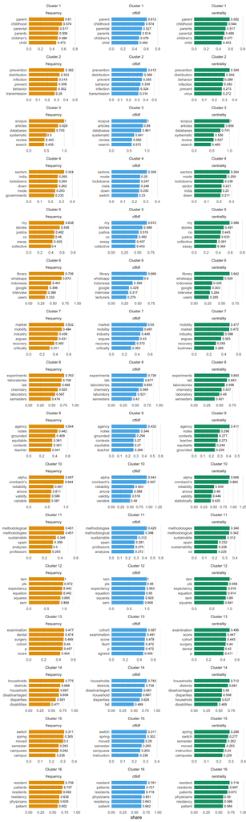

```r
plot(views, value = "share")
```

```r
attention <- hg_hypergat(abstracts, labels = topics, column = "Abstract",
                         id = "doc", epochs = 10, seed = 1,
                         what = "attention")
fit <- hg_hypergat(abstracts, labels = topics, column = "Abstract", id = "doc",
                   epochs = 10, seed = 1)
mean(fit$predicted == fit$label)
```

```
[1] 0.9683579
```

```r
hg_keywords(hg, topics, n = 8, scores = attention,
            sort_by = "share", min_docs = 15, collapse = TRUE)
```

```
 type      cluster    size words
 attention Cluster 1  243  parent, childhood, parents, children's, parental...
 attention Cluster 2  197  prevention, prevent, transmission, infection, vi...
 attention Cluster 3  130  scopus, articles, databases, systematic, review,...
 attention Cluster 4  249  sectors, india, governments, lockdowns, sector, ...
 attention Cluster 5  240  my, stories, justice, essay, co, collective, nar...
 attention Cluster 6  274  library, whatsapp, indonesia, google, interview,...
 attention Cluster 7  252  market, mobility, industry, argues, critically, ...
 attention Cluster 8  288  experiments, lab, chemistry, laboratory, laborat...
 attention Cluster 9  324  agency, grounded, contexts, notes, lived, equita...
 attention Cluster 10 234  alpha, cronbach's, reliability, anova, validity,...
 attention Cluster 11 259  methodological, methodologies, sustainable, anal...
 attention Cluster 12 156  tam, pls, equation, expectancy, sem, squares, in...
 attention Cluster 13 149  examination, cohort, surgery, dental, score, sco...
 attention Cluster 14 246  households, household, districts, disadvantaged,...
 attention Cluster 15 257  campuses, switch, moved, spring, semester, campu...
 attention Cluster 16 168  resident, residents, patients, physicians, patie...
```

# Topics across the pandemic years

Each abstract carries its publication year, so the partition doubles as a lens on how the literature moved. Sixteen topics cannot be told apart by colour, so each topic gets its own panel: the bar is the topic’s share of that year’s abstracts, labelled by the three words the topic owns most. 2023 holds 105 abstracts and should be read with that in mind; 2024, with five, is left to the count table.

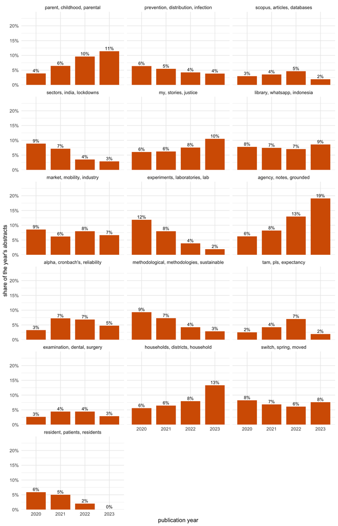

```r
labels <- hg_keywords(hg, topics, n = 3, type = "frequency",
                      sort_by = "share", min_docs = 15, collapse = TRUE)
year_topic <- merge(topics, subset(abstracts, select = c(doc, Year)),
                    by.x = "node", by.y = "doc")
year_n <- as.data.frame(table(Year = year_topic$Year))
shown <- subset(merge(year_topic, year_n, by = "Year"), Freq >= 30)
composition <- as.data.frame(
  prop.table(table(shown$Year, shown$cluster), margin = 1)
)
names(composition) <- c("year", "cluster", "share")
composition <- merge(composition, labels, by = "cluster")
composition$topic <- factor(composition$words, levels = labels$words)
composition$label <- sprintf("%.0f%%", 100 * composition$share)
ggplot2::ggplot(composition,
                ggplot2::aes(x = .data$year, y = .data$share)) +
  ggplot2::geom_col(fill = okabe_ito[5], width = 0.8) +
  ggplot2::geom_text(ggplot2::aes(label = .data$label), vjust = -0.4,
                     size = 3) +
  ggplot2::facet_wrap(ggplot2::vars(.data$topic), ncol = 3) +
  ggplot2::scale_y_continuous(labels = \(x) sprintf("%.0f%%", 100 * x),
                              expand = ggplot2::expansion(mult = c(0, .3))) +
  ggplot2::labs(x = "publication year", y = "share of the year's abstracts") +
  ggplot2::theme_minimal(base_size = 11) +
  ggplot2::theme(strip.text = ggplot2::element_text(size = 9))
```

```r
knitr::kable(
  as.data.frame.matrix(table(year_topic$Year, year_topic$cluster)),
  caption = "Abstracts per year and topic"
)
```

Abstracts per year and topic

|  | Cluster 1 | Cluster 10 | Cluster 11 | Cluster 12 | Cluster 13 | Cluster 14 | Cluster 15 | Cluster 16 | Cluster 2 | Cluster 3 | Cluster 4 | Cluster 5 | Cluster 6 | Cluster 7 | Cluster 8 | Cluster 9 |
| --- | --- | --- | --- | --- | --- | --- | --- | --- | --- | --- | --- | --- | --- | --- | --- | --- |
| 2020 | 25 | 21 | 60 | 16 | 17 | 36 | 53 | 38 | 41 | 19 | 57 | 39 | 50 | 55 | 76 | 40 |
| 2021 | 153 | 171 | 173 | 100 | 105 | 153 | 163 | 119 | 129 | 84 | 169 | 148 | 176 | 146 | 189 | 194 |
| 2022 | 52 | 37 | 23 | 38 | 24 | 43 | 33 | 11 | 23 | 25 | 19 | 41 | 38 | 43 | 21 | 70 |
| 2023 | 12 | 5 | 3 | 2 | 3 | 14 | 8 | 0 | 4 | 2 | 3 | 11 | 9 | 7 | 2 | 20 |
| 2024 | 1 | 0 | 0 | 0 | 0 | 0 | 0 | 0 | 0 | 0 | 1 | 1 | 1 | 1 | 0 | 0 |

# Document scope against sentence scope, at sixteen topics

The centrality view above relates two words when they share an abstract. `text_hypergraph(construction = "sentence")` builds the finer relation: words are nodes and every sentence is a hyperedge, so two words are linked only when they share a sentence. Passed to `hg_keywords()` in place of the document hypergraph, with the same partition, it ranks each topic’s words by their centrality among the topic’s sentences rather than its abstracts. The comparison uses the same sixteen topics as the rest of the document.

```r
sh <- text_hypergraph(abstracts, column = "Abstract", id = "doc",
                      construction = "sentence", stop_words = stops,
                      min_count = 5L, sparse = TRUE)
sh
```

```
Text hypergraph: 3666 documents, 6232 words (sentence hyperedges: 30637 sentences)
Hyperedges: 30637 (sentences); sizes 1-74, median 12
```

```r
document_scope <- hg_keywords(hg, topics, n = 8, type = "centrality",
                              sort_by = "share", min_docs = 15)
sentence_scope <- hg_keywords(sh, topics, n = 8, type = "centrality",
                              sort_by = "share", min_docs = 15)
document_scope
```

```
 type       cluster    size words
 centrality Cluster 1  243  parent, childhood, parents, parental, children'...
 centrality Cluster 2  197  prevention, distribution, behavior, infection, ...
 centrality Cluster 3  130  scopus, articles, databases, systematic, review...
 centrality Cluster 4  249  sectors, mode, lockdowns, sector, india, down, ...
 centrality Cluster 5  240  my, stories, co, justice, collective, essay, re...
 centrality Cluster 6  274  library, whatsapp, indonesia, google, interview...
 centrality Cluster 7  252  mobility, market, industry, argues, recovery, b...
 centrality Cluster 8  288  experiments, lab, laboratories, chemistry, labo...
 centrality Cluster 9  324  agency, notes, contexts, teacher, equitable, gr...
 centrality Cluster 10 234  alpha, cronbach's, reliability, anova, validity...
 centrality Cluster 11 259  methodologies, methodological, sustainable, spa...
 centrality Cluster 12 156  tam, pls, expectancy, equation, sem, squares, i...
 centrality Cluster 13 149  examination, score, cohort, surgery, dental, p,...
 centrality Cluster 14 246  households, districts, disadvantaged, dispariti...
 centrality Cluster 15 257  spring, switch, semester, moved, instruction, c...
 centrality Cluster 16 168  resident, residents, patients, physicians, resi...
128 rows in the long form (rank, score, share, n_docs): as.data.frame()
```

```r
sentence_scope
```

```
 type       cluster    size words
 centrality Cluster 1  243  parent, childhood, parents, parental, children'...
 centrality Cluster 2  197  prevention, behavior, infection, prevent, virus...
 centrality Cluster 3  130  scopus, articles, databases, systematic, review...
 centrality Cluster 4  249  sectors, mode, india, sector, lockdowns, down, ...
 centrality Cluster 5  240  my, stories, justice, co, collective, essay, i,...
 centrality Cluster 6  274  library, whatsapp, indonesia, google, lecturers...
 centrality Cluster 7  252  market, mobility, industry, argues, recovery, b...
 centrality Cluster 8  288  experiments, lab, laboratories, chemistry, labo...
 centrality Cluster 9  324  agency, notes, teacher, equitable, contexts, er...
 centrality Cluster 10 234  alpha, cronbach's, reliability, anova, statisti...
 centrality Cluster 11 259  methodologies, methodological, sustainable, pro...
 centrality Cluster 12 156  tam, pls, expectancy, equation, sem, squares, i...
 centrality Cluster 13 149  p, surgery, examination, cohort, dental, score,...
 centrality Cluster 14 246  households, districts, disadvantaged, household...
 centrality Cluster 15 257  spring, switch, semester, moved, instruction, c...
 centrality Cluster 16 168  resident, residents, patients, residency, patie...
128 rows in the long form (rank, score, share, n_docs): as.data.frame()
```

```r
shared <- merge(document_scope, sentence_scope, by = c("cluster", "word"))
overlap <- table(factor(shared$cluster, levels = unique(document_scope$cluster)))
overlap
```

```
 Cluster 1  Cluster 2  Cluster 3  Cluster 4  Cluster 5  Cluster 6  Cluster 7
         8          7          8          8          8          8          7
 Cluster 8  Cluster 9 Cluster 10 Cluster 11 Cluster 12 Cluster 13 Cluster 14
         7          8          8          7          8          8          7
Cluster 15 Cluster 16
         7          8
```

```r
mean(overlap)
```

```
[1] 7.625
```

The two scopes share seven or eight of eight words in every one of the sixteen topics. Ranked by share, a topic’s *owned* vocabulary is what surfaces under either scope, and centrality only orders it; the finer co-occurrence relation changes that order at the margin. Sentence scope does not remove the corpus vocabulary either: ranked by raw centrality instead of share, “learning”, “students”, “education” and “online” top every topic under both scopes, because the words of the whole corpus are also the words of most sentences.

```r
word_bag <- text_hypergraph(abstracts, column = "Abstract", id = "doc",
                            nodes = "word", stop_words = stops,
                            min_count = 5L, sparse = TRUE)
communities <- lapply(list(document = word_bag, sentence = sh), \(h) {
  parts <- hg_cluster(h, k = 16, seed = 1)
  weights <- as.data.frame(h, what = "weights")
  degree <- tapply(weights$weight, weights$word, sum)
  sizes <- sort(table(parts$cluster), decreasing = TRUE)
  data.frame(
    community = names(sizes),
    n_words = as.integer(sizes),
    top_words = vapply(names(sizes), \(cl) {
      w <- parts$node[parts$cluster == cl]
      paste(utils::head(w[order(-degree[w])], 6), collapse = ", ")
    }, character(1))
  )
})
knitr::kable(communities$document, row.names = FALSE,
             caption = "Word communities, document scope (words as nodes, abstracts as hyperedges)")
```

Word communities, document scope (words as nodes, abstracts as hyperedges)

| community | n_words | top_words |
| --- | --- | --- |
| Cluster 11 | 550 | social, article, critical, i, ways, times |
| Cluster 7 | 505 | education, higher, paper, impact, institutions, crisis |
| Cluster 3 | 500 | educational, based, digital, process, different, knowledge |
| Cluster 6 | 468 | face, new, schools, universities, time, due |
| Cluster 5 | 439 | teachers, research, challenges, remote, findings, support |
| Cluster 2 | 434 | information, resources, management, various, platforms, lack |
| Cluster 15 | 414 | students, learning, online, teaching, university, experience |
| Cluster 1 | 395 | future, development, approach, design, skills, need |
| Cluster 8 | 393 | school, access, children, groups, particularly, low |
| Cluster 16 | 385 | distance, well, conducted, related, home, parents |
| Cluster 4 | 362 | health, medical, training, clinical, programs, care |
| Cluster 10 | 342 | student, survey, academic, faculty, assessment, year |
| Cluster 13 | 328 | data, using, used, analysis, significant, level |
| Cluster 9 | 305 | two, authors, literature, science, field, included |
| Cluster 12 | 281 | use, technology, e, model, self, factors |
| Cluster 14 | 131 | work, provided, open, under, terms, although |

```r
knitr::kable(communities$sentence, row.names = FALSE,
             caption = "Word communities, sentence scope (words as nodes, sentences as hyperedges)")
```

Word communities, sentence scope (words as nodes, sentences as hyperedges)

| community | n_words | top_words |
| --- | --- | --- |
| Cluster 7 | 835 | education, educational, higher, challenges, digital, new |
| Cluster 8 | 727 | social, crisis, implications, systems, policy, economic |
| Cluster 5 | 620 | paper, process, emergency, public, context, strategies |
| Cluster 3 | 587 | learning, teaching, face, distance, remote, schools |
| Cluster 4 | 543 | health, use, findings, support, technology, impact |
| Cluster 2 | 445 | survey, two, participants, conducted, out, questionnaire |
| Cluster 6 | 402 | e, skills, knowledge, level, self, positive |
| Cluster 1 | 392 | research, universities, experiences, response, across, various |
| Cluster 13 | 367 | students, online, teachers, school, university, virtual |
| Cluster 10 | 288 | clinical, reported, pre, overall, years, number |
| Cluster 11 | 278 | significant, satisfaction, perceived, revealed, performance, showed |
| Cluster 15 | 223 | data, using, used, analysis, approach, design |
| Cluster 16 | 219 | based, student, one, different, related, assessment |
| Cluster 14 | 137 | model, theory, analyze, models, relationships, analyses |
| Cluster 12 | 101 | medical, work, article, access, provided, open |
| Cluster 9 | 68 | closed, discusses, plan, beginning, plans, respond |

# Reading it